# MS4610 Group No. 19 IDA Project: Loan Default Prediction

### 7US) Comparing Model performance using ROC & AUC

Let's use Receiver Operating Characteristic (ROC) curve and find the Area Under Curve (AUC) to evaluate the performance of our models with False postive ratio/True positive ratio.

```python
#Perform Predictions for all the models
PRED_PROB_LOG_RAW=logmodelus.predict_proba(X_upsampled_test)
PRED_PROB_KNN_RAW=knn_modelus.predict_proba(X_upsampled_test)
PRED_PROB_NB_RAW=nb_modelus.predict_proba(X_upsampled_test)
PRED_PROB_RF_RAW=rfmodelus.predict_proba(X_upsampled_test)
PRED_PROB_DT_RAW=dtmodelus.predict_proba(X_upsampled_test)
PRED_PROB_XG_RAW=xgmodelus.predict_proba(X_upsampled_test)
```

```python
#calculate fpr,tpr,threshold
fpr1, tpr1, thresh1 = roc_curve(Y_upsampled_test, PRED_PROB_LOG_RAW[:,1], pos_label=1)
fpr2,tpr2,thresh2 = roc_curve(Y_upsampled_test, PRED_PROB_KNN_RAW[:,1], pos_label=1)
fpr3,tpr3,thresh3 = roc_curve(Y_upsampled_test, PRED_PROB_NB_RAW[:,1], pos_label=1)
fpr4,tpr4,thresh4 = roc_curve(Y_upsampled_test, PRED_PROB_RF_RAW[:,1], pos_label=1)
fpr5,tpr5,thresh5 = roc_curve(Y_upsampled_test, PRED_PROB_DT_RAW[:,1], pos_label=1)
fpr6,tpr6,thresh6 = roc_curve(Y_upsampled_test, PRED_PROB_XG_RAW[:,1], pos_label=1)

random_probs = [0 for i in range(len(Y_upsampled_test))]
p_fpr, p_tpr, _ = roc_curve(Y_upsampled_test, random_probs, pos_label=1)


AUC_LOG_RAW = roc_auc_score(Y_upsampled_test,PRED_PROB_LOG_RAW[:,1])
AUC_KNN_RAW = roc_auc_score(Y_upsampled_test,PRED_PROB_KNN_RAW[:,1])
AUC_NB_RAW = roc_auc_score(Y_upsampled_test,PRED_PROB_NB_RAW[:,1])
AUC_RF_RAW = roc_auc_score(Y_upsampled_test,PRED_PROB_RF_RAW[:,1])
AUC_DT_RAW = roc_auc_score(Y_upsampled_test,PRED_PROB_DT_RAW[:,1])
AUC_XG_RAW = roc_auc_score(Y_upsampled_test,PRED_PROB_XG_RAW[:,1])

AUC_SCORES=pd.array([AUC_LOG_RAW, AUC_KNN_RAW, AUC_NB_RAW, AUC_RF_RAW, AUC_DT_RAW, AUC_XG_RAW])
```

```
The ROC Curve and the Final Report card for the Upsampled Data is here:
```

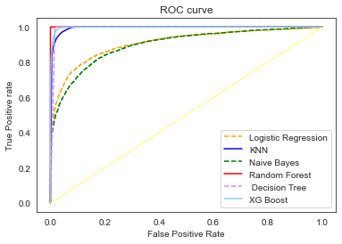

```
ROC_AUC_Score for Logistic Regression is: 0.908120948024452
ROC_AUC_Score for KNN is: 0.993781834610127
ROC_AUC_Score for Naive Bayes is: 0.8981291929794514
ROC_AUC_Score for Random Forest is: 0.999857121837064
ROC_AUC_Score for Decision Tree is: 0.9916854565952649
ROC_AUC_Score for XG Boost is: 0.9973886747372799
The Best ROC_AUC_Score is :0.999857121837064 for Random Forest Classifier
```

```python
#Plot Area Under Curve

plt.plot(fpr1,tpr1,linestyle='--',color='orange', label='Logistic Regression')
plt.plot(fpr2,tpr2,linestyle='solid',color='blue', label='KNN')
plt.plot(fpr3,tpr3,linestyle='--',color='Green', label='Naive Bayes')
plt.plot(fpr4,tpr4,linestyle='solid',color='Red', label='Random Forest')
plt.plot(fpr5,tpr5,linestyle='--',color='violet',label=' Decision Tree')
plt.plot(fpr6,tpr6,linestyle='solid',color='skyblue',label='XG Boost')

print('The ROC Curve and the Final Report card for the Upsampled Data is here:')

plt.plot(p_fpr, p_tpr, linestyle=':', color='Yellow')
plt.title('ROC curve')
plt.xlabel('False Positive Rate')
plt.ylabel('True Positive rate')

plt.legend(loc='best')
plt.show();

print("ROC_AUC_Score for Logistic Regression is: {}".format(AUC_LOG_RAW))
print("ROC_AUC_Score for KNN is: {}".format(AUC_KNN_RAW))
print("ROC_AUC_Score for Naive Bayes is: {}".format(AUC_NB_RAW))
print("ROC_AUC_Score for Random Forest is: {}".format(AUC_RF_RAW))
print("ROC_AUC_Score for Decision Tree is: {}".format(AUC_DT_RAW))
print("ROC_AUC_Score for XG Boost is: {}".format(AUC_XG_RAW))

print("*******************************************************************")

d = {'Logistice Regression': AUC_LOG_RAW, 'KNN': AUC_KNN_RAW, 'Naive Bayes': AUC_NB_RAW, 'Decision Trees': AUC_DT_RAW,
      'Random Forest': AUC_RF_RAW, 'XGBoost': AUC_XG_RAW}
l = list(d.values())
for i in list(d.keys()):
    if d[i] == AUC_SCORES.max():
        ROC_AUC_Model = i

print("The Best ROC_AUC_Score is :{} for {} Classifier".format(AUC_SCORES.max(), ROC_AUC_Model))
```

**Conclusion**:

Now, The Random Forest Classifier Model has the highest AUC score, so does the ROC curve too.

By checking the Accuracy, Precision, Recall, ROC & AUC; the **Random Forest** Classifier Model appears to be the best model on the Upsampled dataset as well.

### 8) Final Conclusion for the Project:

- The given data was assessed using a thorough Exploratory Data Analysis.
- For each of the features, Skewness and Outlier Analysis was performed.
- Our target column had high imbalance which would result into a biased model. Upsampling technique was used to mitigate this issue.
- Standardization was performed to increase the learning performance of the model.
- A total of 6 models were tested on the main original data as well as the upsampled data.
- The **Random Forest Classifier** is the best Model for the classification purpose.